# Can a 10-euro sensor replace a 100,000-euro analyser? Calibrating low-cost air quality sensors

## 4. Drift: how fast does a calibration go stale?

The error of the **static** models (fitted once, in 2004) against the **weekly re-calibrated** one, month by month through the test period. If the sensors or the environment change, the static error and the bias should grow.

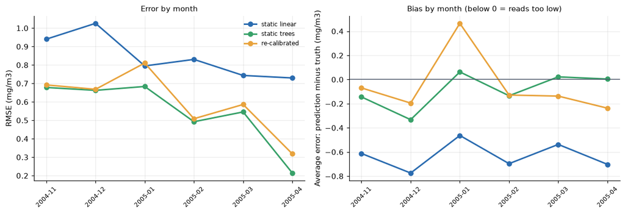

| time | 2004-11 | 2004-12 | 2005-01 | 2005-02 | 2005-03 | 2005-04 |
| --- | --- | --- | --- | --- | --- | --- |
| static linear | 0.94 | 1.03 | 0.79 | 0.83 | 0.74 | 0.73 |
| static trees | 0.68 | 0.66 | 0.68 | 0.49 | 0.55 | 0.21 |
| re-calibrated | 0.69 | 0.67 | 0.81 | 0.51 | 0.59 | 0.32 |

```python
static_linear, static_trees, recal = preds_co["All sensors + weather, linear"], preds_co["Gradient-boosted trees"], preds_co["Weekly re-calibration (linear)"]
frame = pd.DataFrame({"truth": test_co.CO.to_numpy(), "static linear": static_linear, "static trees": static_trees, "re-calibrated": recal}, index=test_co.index)
monthly = frame.groupby(frame.index.to_period("M"))
rmse_by_month = pd.DataFrame({c: monthly.apply(lambda g: np.sqrt(np.mean((g[c] - g.truth) ** 2))) for c in ["static linear", "static trees", "re-calibrated"]})
bias_by_month = pd.DataFrame({c: monthly.apply(lambda g: np.mean(g[c] - g.truth)) for c in ["static linear", "static trees", "re-calibrated"]})
months = [str(m) for m in rmse_by_month.index]

fig, axes = plt.subplots(1, 2, figsize=(11.5, 4))
for col, color in zip(rmse_by_month.columns, [BLUE, "#38a169", AMBER]):
    axes[0].plot(months, rmse_by_month[col], marker="o", color=color, label=col, lw=2)
    axes[1].plot(months, bias_by_month[col], marker="o", color=color, label=col, lw=2)
axes[0].set_ylabel("RMSE (mg/m3)")
axes[0].set_title("Error by month", fontsize=10)
axes[0].legend(frameon=False, fontsize=8)
axes[1].axhline(0, color="#4a5568", lw=1)
axes[1].set_ylabel("Average error: prediction minus truth (mg/m3)")
axes[1].set_title("Bias by month (below 0 = reads too low)", fontsize=10)
for ax in axes:
    ax.tick_params(axis="x", rotation=45, labelsize=8)
fig.tight_layout()
plt.show()
rmse_by_month.round(2).T
```

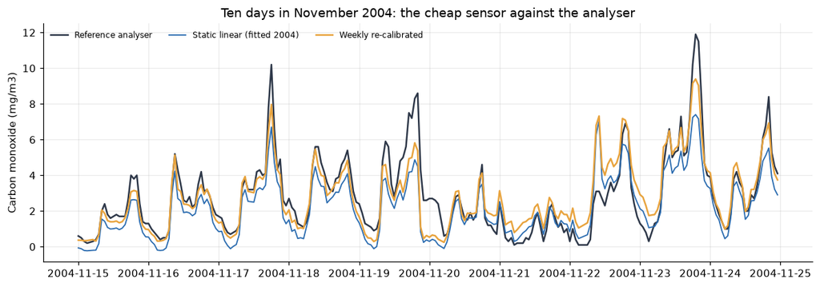

```python
w = frame.loc["2004-11-15":"2004-11-24"]
fig, ax = plt.subplots(figsize=(11, 3.9))
ax.plot(w.index, w.truth, color="#2d3748", lw=1.6, label="Reference analyser")
ax.plot(w.index, w["static linear"], color=BLUE, lw=1.2, label="Static linear (fitted 2004)")
ax.plot(w.index, w["re-calibrated"], color=AMBER, lw=1.6, label="Weekly re-calibrated")
ax.set_ylabel("Carbon monoxide (mg/m3)")
ax.set_title("Ten days in November 2004: the cheap sensor against the analyser")
ax.legend(frameon=False, ncol=3, fontsize=8)
fig.tight_layout()
plt.show()
```

## 5. Which gases can be calibrated best?

The same four models for benzene, nitrogen dioxide and nitrogen oxides. Gases whose sensors respond less specifically, or whose analyser data is noisier, are harder.

```python
rows = {}
for target in ["CO", "benzene", "NO2", "NOx"]:
    te, preds = run(target)
    for name, p in preds.items():
        rows[(target, name)] = score(te[target].to_numpy(), p)
all_gases = pd.DataFrame(rows).T
all_gases.index.names = ["gas", "model"]
r2_table = all_gases.R2.unstack("model")[["One sensor, linear", "All sensors + weather, linear", "Gradient-boosted trees", "Weekly re-calibration (linear)"]]
r2_table.round(3)
```

| model gas | One sensor, linear | All sensors + weather, linear | Gradient-boosted trees | Weekly re-calibration (linear) |
| --- | --- | --- | --- | --- |
| CO | 0.715 | 0.695 | 0.849 | 0.826 |
| NO2 | -2.351 | 0.495 | -0.179 | 0.622 |
| NOx | -0.421 | -0.427 | 0.676 | 0.866 |
| benzene | 0.956 | 0.799 | 0.995 | 0.970 |

## 6. What does the best static model rely on?

**Permutation importance**: shuffle one input at a time on the test months and see how much the error grows.

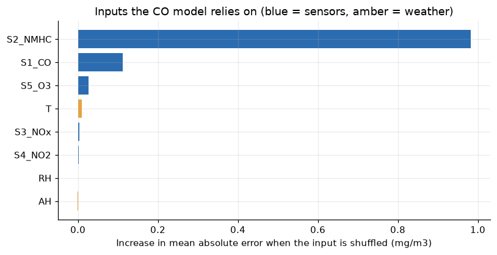

|  | extra error |
| --- | --- |
| S2_NMHC | 0.982 |
| S1_CO | 0.112 |
| S5_O3 | 0.026 |
| T | 0.010 |
| S3_NOx | 0.003 |
| S4_NO2 | 0.002 |
| RH | 0.000 |
| AH | -0.001 |

```python
from sklearn.inspection import permutation_importance

tr, va, te = split("CO")
trva = pd.concat([tr, va])
forest = HistGradientBoostingRegressor(learning_rate=0.05, max_leaf_nodes=8, max_iter=300, random_state=0).fit(trva[FEATURES], trva.CO)
imp = permutation_importance(forest, te[FEATURES], te.CO, n_repeats=5, random_state=0, scoring="neg_mean_absolute_error")
importance = pd.Series(imp.importances_mean, index=FEATURES).sort_values()
fig, ax = plt.subplots(figsize=(7.5, 3.9))
ax.barh(importance.index, importance.values, color=[BLUE if f in SENSORS else AMBER for f in importance.index])
ax.set_xlabel("Increase in mean absolute error when the input is shuffled (mg/m3)")
ax.set_title("Inputs the CO model relies on (blue = sensors, amber = weather)")
fig.tight_layout()
plt.show()
importance.sort_values(ascending=False).round(3).to_frame("extra error")
```

## What the results say

**Limits:** one device at one roadside location over one year, so conclusions about drift and seasons rest on a single deployment; hours without a reference reading (18% for CO) are removed and may not be missing at random; the weekly re-calibration assumes that reference readings of the previous eight weeks are available, which a real network may not have; the test period is both later and different in season, so drift and seasonality are mixed together; R2 is reported without confidence intervals.

**Techniques covered:** cleaning a missing-value code, time-based train, validation and test split, linear regression and gradient boosting, a rolling re-calibration loop, error and bias by month, permutation importance and a comparison across four target gases.